# Análisis de Desempeño Estudiantil

## Colegio Universitario de Cartago

### Exploración de Datos (BD - 142)

### **Realizado por:** Sharon Obando Gómez, Camila Jiménez Gómez y Wedell Orozco González

### **Docente:** Osvaldo Gonzáles Chaves

### Fecha presentación de proyecto: 21/08/2025

# Librerias

```r
library(XLConnect)
library(echarts4r)
library(echarts4r.assets)
library(caret)
library(loadeR)
library(FactoMineR)
library(discoveR)
library(dplyr)
library(fastDummies)
```

# Acerca del datasets

Este estudio analiza el rendimiento estudiantil en educación secundaria en dos escuelas portuguesas. Los atributos de los datos incluyen calificaciones estudiantiles, características demográficas, sociales y escolares, y se recopilaron mediante informes escolares y cuestionarios. Se proporcionan dos conjuntos de datos sobre el rendimiento en dos asignaturas distintas: Matemáticas y Portugués. En [Cortez y Silva, 2008], ambos conjuntos de datos se modelaron bajo tareas de clasificación y regresión binaria/de cinco niveles.

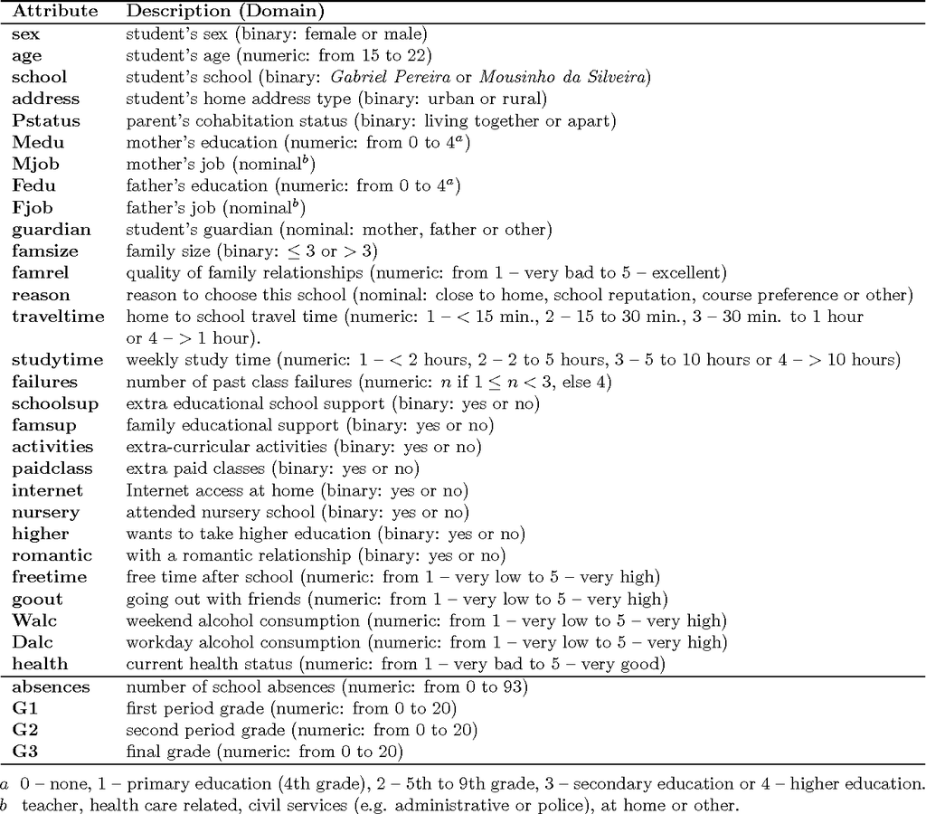

```r
#Data de los estudiantes de matematicas
d1=read.table("student-mat.csv",sep=";",header=TRUE)
sum(is.na(d1))
```

```
## [1] 0
```

```r
dim(d1)
```

```
## [1] 395  33
```

```r
#Datos de los estudiantes de portugues
d2=read.table("student-por.csv",sep=";",header=TRUE)
sum(is.na(d1))
```

```
## [1] 0
```

```r
dim(d2)
```

```
## [1] 649  33
```

```r
#Unión de los datos(solo estudiantes que cursan matematicas y portugues)
d3=merge(d1,d2,by=c("school","sex","age","address","famsize","Pstatus","Medu","Fedu","Mjob","Fjob","reason","nursery","internet"))
sum(is.na(d3))
```

```
## [1] 0
```

```r
dim(d3)
```

```
## [1] 382  53
```

```r
#Renombrar columnas
names(d3) <- gsub("\\.x$", "_math", names(d3))
names(d3) <- gsub("\\.y$", "_port", names(d3))
```

# Fase #1

## Objetivo General:

Analizar el rendimiento académico de estudiantes a partir de información académica, familiar y de hábitos de estudio, identificando perfiles de alto y bajo desempeño, con el fin de determinar qué factores influyen en el rendimiento académico.

## Objetivo Especifico:

- Rendimiento académico de parte de las instituciones
- Analizar aquellas actividades realizadas por los estudiantes que pueden llegar a afectar positiva o negativamente su desempeño a nivel académico en las asignaturas de Matemáticas y Portugés.

# Fase #2

## Primer Periodo

```r
e_histboxplot(d3[['G1_math']], 'G1_math', '#4682B4', '#FF0000', c('minimo', 'Primer Cuartil', 'mediana', 'Tercer Cuartil', 'maximo'))
```

[interactive chart not shown]

Podemos ver que en la distribución de este primer periodo en la materia de matematicas (G1_math) se obtuvieron datos como una media de 10 de nota como rango minimo que uno o algunos estudiantes obtuvieron fue de 3 y como rango maximo de igual forma que uno o algunos estudiantes optuvieron fue de 19.

```r
e_histboxplot(d3[['G1_port']], 'G1_port', '#4682B4', '#FF0000', c('minimo', 'Primer Cuartil', 'mediana', 'Tercer Cuartil', 'maximo'))
```

[interactive chart not shown]

Podemos ver que en la distribución de este primer periodo en la materia de portugues (G1_port) se obtuvieron datos como una media de 12 de nota como rango minimo que uno o algunos estudiantes obtuvieron fue de 0 y como rango maximo de igual forma que uno o algunos estudiantes optuvieron fue de 19.

## Segundo Periodo

```r
e_histboxplot(d3[['G2_math']], 'G2_math', '#4682B4', '#FF0000', c('minimo', 'Primer Cuartil', 'mediana', 'Tercer Cuartil', 'maximo'))
```

[interactive chart not shown]

Podemos ver que en la distribución de este segundo periodo en la materia de matematicas (G2_math) se obtuvieron datos como una media de 11 de nota como rango minimo que uno o algunos estudiantes obtuvieron fue de 5 y como rango maximo de igual forma que uno o algunos estudiantes optuvieron fue de 19.

```r
e_histboxplot(d3[['G2_port']], 'G2_port', '#4682B4', '#FF0000', c('minimo', 'Primer Cuartil', 'mediana', 'Tercer Cuartil', 'maximo'))
```

[interactive chart not shown]

Podemos ver que en la distribución de este segundo periodo en la materia de portugues (G2_port) se obtuvieron datos como una media de 12 de nota como rango minimo que uno o algunos estudiantes obtuvieron fue de 7 y como rango maximo de igual forma que uno o algunos estudiantes optuvieron fue de 18.

## Tercer Periodo

```r
e_histboxplot(d3[['G3_math']], 'G3_math', '#4682B4', '#FF0000', c('minimo', 'Primer Cuartil', 'mediana', 'Tercer Cuartil', 'maximo'))
```

[interactive chart not shown]

Podemos ver que en la distribución de este tercer periodo en la materia de matematicas (G3_math) se obtuvieron datos como una media de 11 de nota como rango minimo que uno o algunos estudiantes obtuvieron fue de 0 y como rango maximo de igual forma que uno o algunos estudiantes optuvieron fue de 20.

```r
e_histboxplot(d3[['G3_port']], 'G3_port', '#4682B4', '#FF0000', c('minimo', 'Primer Cuartil', 'mediana', 'Tercer Cuartil', 'maximo'))
```

[interactive chart not shown]

Podemos ver que en la distribución de este tercer periodo en la materia de portugues (G3_port) se obtuvieron datos como una media de 13 de nota como rango minimo que uno o algunos estudiantes obtuvieron fue de 0 y como rango maximo de igual forma que uno o algunos estudiantes optuvieron fue de 18.

# Fase #3

## ACP

### Individuos

```r
### Modelo ACP
modelo.pca <- PCA(var.numericas(d3), scale.unit = TRUE, ncp = 10, graph = F)
```

```r
### Gráfico de individuos ACP (2D)
e_pcaind(modelo.pca, c(1, 2), '#4682B4', 0, '#B22222', c('Bien Representados', 'Mal Representados'))
```

[interactive chart not shown]

### Variables

```r
### Gráfico de variables ACP (2D)
e_pcavar(modelo.pca, c(1, 2), '#228B22', 0, '#9932CC', c('Bien Representados', 'Mal Representados'))
```

[interactive chart not shown]

Variables: (Walc._math - Walc_port) esta variable representa el consumo de alcohol los fines de semana, (Dalc_math - Dalc_port) esta variable representa el consumo de alcohol los días de trabajo, (goout_math - goout_port) esta representa la salida con amigos, (freetime_math - freetime_port) muestra el tiempo libre después de la escuela, (traveltime_math - traveltime_port) indica el tiempo de viaje de la casa a la escuela. Estas son algunas de las variables, las cuales tuvieron una correlación positiva fuerte donde ambas variables tienden a aumentar, pero esto se debe porque, como fue mencionado anteriormente; estos datos son la unión de estudiantes los cuales están llevando la materia de matemática y portugués.

Aún así en algunas variables se tienen variaciones como en la variable (absences_math - absences_port), esta representa el número de ausencias del 0 al 93 aunque, no es que sea un cambio muy drástico, ya que sigue siendo una correlación positiva pero no muy fuerte. Puede deberse a que algunos estudiantes tienen mayor ausencia en alguna de las dos materias. También tenemos un cambio pequeño en la variable (failures_math - failures_port), esta representa el número de suspensiones, al igual que la anterior, el cambio no es muy drástico; tiene una correlación positiva fuerte pero no como las anteriores, esto puede ser que algunos estudiantes suspenden más en una materia que en la otra.

Otra observación interesante es en las variables (G1_math,G2_math,G3_math - G1_port,G2_port,G3_port), esto representa las calificaciones del primer, segundo y tercer periodo donde, a pesar de que sea correlación positiva, es posible que algunos estudiantes tenga una calificación mayor en los distintos periodos más que en la otra materia; de igual forma estas variables como contraparte tiene una correlación negativa con las variables (failures_math - failures_port), esto puede deberse a que, entre mayor veces se suspende, menor es la calificación o viceversa. De igual forma, una correlación negativa con las variables (traveltime_math - traveltime_port), donde nos puede decir que, entre mayor sea la duración en el tiempo de viaje de la casa a la escuela es menor la calificación por temas de distancia, ya que es probable que algunos estudiantes lleguen tarde o por alguna situación climatológica no puedan asistir del todo y pierdan clases/información, las cuales pueda afectar a su desempeño.

### Sobreposición

```r
# Exclusión
columnas_deseadas <- d3 %>%
  select(where(is.numeric), school) %>%
  select(-Medu, -Fedu, -famrel_math, -famrel_port, -health_math, -health_port, -age)


# Nuevo dataframe completamente numérico
datos_pca <- dummy_cols(columnas_deseadas, select_columns = "school")
datos_pca_final<-datos_pca %>%
  select(-school)

# PCA
modelo.pca02 <- PCA(datos_pca_final, scale.unit = TRUE, ncp = 10, graph = FALSE)
### Gráfico de sobreposición ACP (2D)
e_pcabi(modelo.pca02, c(1, 2), '#4682B4', '#228B22', 0, 0, '#B22222', '#9932CC', c('Bien Representados', 'Mal Representados'))
```

[interactive chart not shown]

En la variable “school.GP”, que representa a la escuela Gabriel Pereira, podemos ver una fuerte correlación positiva con las variables(G1_math,G2_math,G3_math - G1_port,G2_port,G3_port), pero vemos un punto destacado en las variables (G1_port,G2_port,G3_port) en donde ambas variables aumentan; esto nos puede decir que los estudiantes que son de esta escuela tienden a tener buenas calificaciones en la materia de portugués y de matemática aunque mayormente en portugués.

```r
# Exclusión
columnas_deseadas02 <- d3 %>%
  select(where(is.numeric), school,address) %>%
  select(-Medu, -Fedu, -famrel_math, -famrel_port, -health_math, -health_port, -age)


# Nuevo dataframe completamente numérico
datos_pca02 <- dummy_cols(columnas_deseadas02, select_columns = c("school", "address"))
datos_pca_final02<-datos_pca02 %>%
  select(-school, -address)

# PCA
modelo.pca03 <- PCA(datos_pca_final02, scale.unit = TRUE, ncp = 10, graph = FALSE)
### Gráfico de sobreposición ACP (2D)
e_pcabi(modelo.pca03, c(1, 2), '#4682B4', '#228B22', 0, 0, '#B22222', '#9932CC', c('Bien Representados', 'Mal Representados'))
```

[interactive chart not shown]

Observaciones destacables que podemos observar es que la escuela o variable school_GP Gabriel Pereira tiene una fuerte correlación positiva con la variable addres_U la cual representa estudiantes que su dirección o ubicacion es urbana lo que nos puede decir que un alto porcentaje de los estudiantes de esta institución son del area urbana.

Otra de las de las observaciones enfocada en la otra institución la escuela o variable school_MS Mousinho da Silveira vemos esta correlación positiva entre la variable school_MS y Address_R la cual representa estudiantes que su dirección o ubicacion es rural lo que nos puede decir que una alta cantidad de estudiantes que pertenencen a la escuela Mousinho da Silveira viven en el area rural

## Perfiles de fila

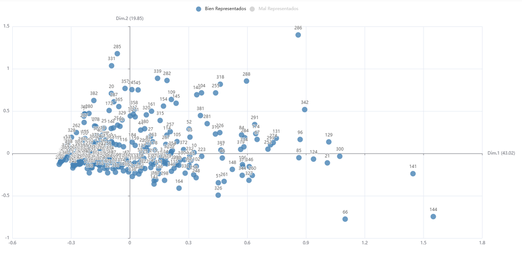

En el perfil de filas se puede observar que la mayoría de estudiantes se conservan del lado izquierdo, sin embargo existe otro grupo de estudiantes que si se van saliendo de esa “normalidad” dentro del conjunto. Se puede decir que estos estudiantes que se alejan del conjunto son aquellos que más ausencias tienen o que han reprobado algunas de las materias de Matemática y Portugés.

## Perfil de columnas

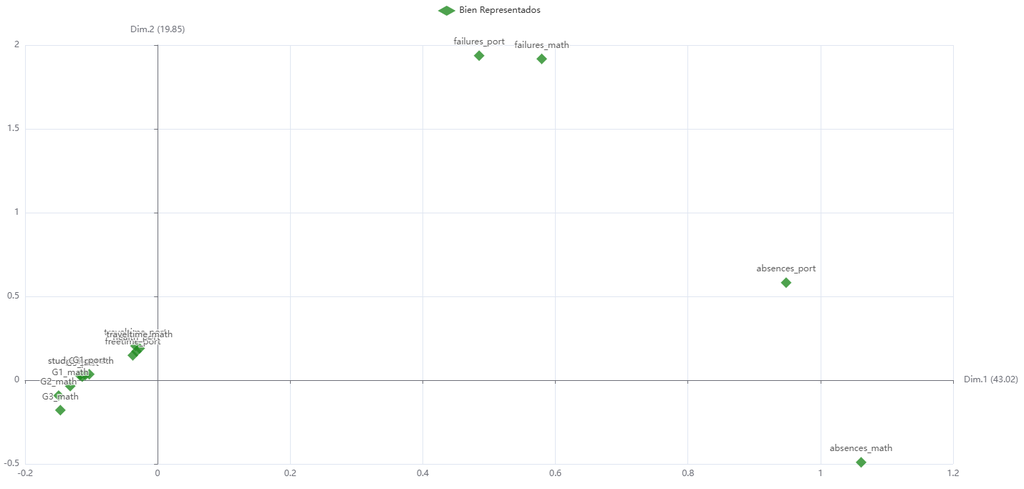

Aquí se observan las variables (columnas) que se utilizaron. Por un lado (izquierda) están el tiempo de viaje, el tiempo dedicado al estudio y los promedios, y por otro lado las ausencias y más arriba se muestra las veces que se reprobó la materia.

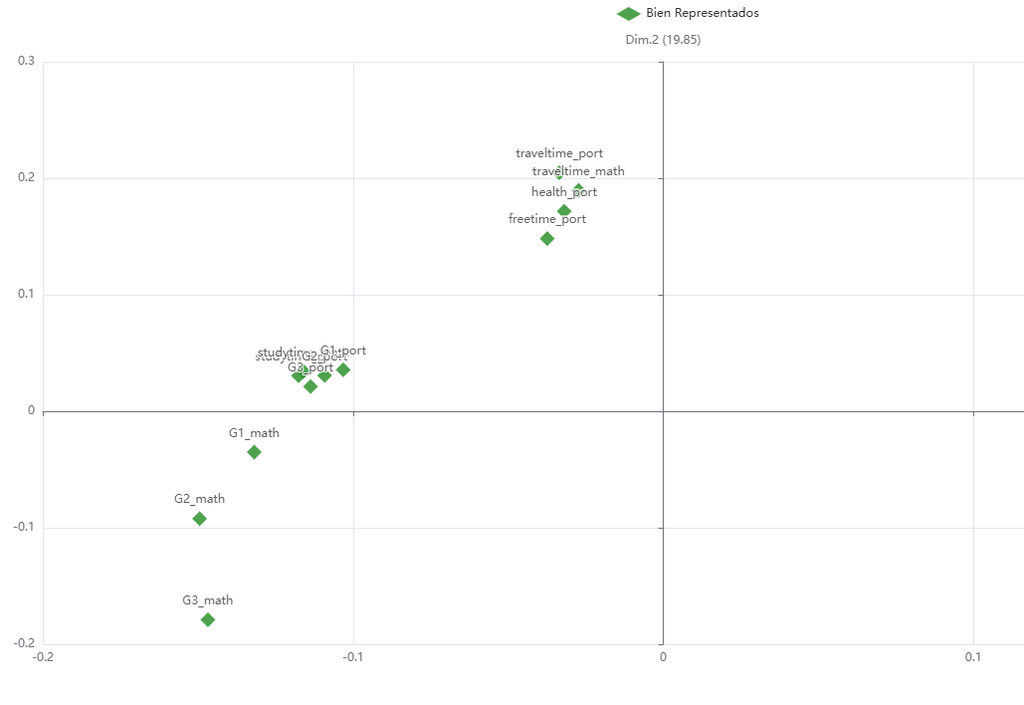

Más detalladamente se puede observar que en el caso de la materia de matemática se encuentra un patrón que muestra un progreso en el promedio de dicha materia. Al inicio el primer promedio (G1) es un poco bajo, pero este va en aumento hasta elevar el promedio final de dicha materia (G3). Este no es el caso de Portugués, ya que se muestra muy similar en todo tiempo a lo largo del periodo. Sin embargo, a ambas materias se les está dedicando un tiempo similar de estudio, a pesar de que el tiempo de traslado (viaje) sea alto.